# Exploratory Analysis

Juliana Beker Godoy, MSc Graduate Program in Bioinformatics Professional and Technological Education Sector Federal University of Parana (UFPR) Curitiba, Brazil

2025-06-02

> Bulk RNAseq dataset | 1,210 unique samples | DLPFC region | ROSMAP cohort

```r
# head(pheno_DLPFC)
# table(pheno_DLPFC$cogdx_3grp)

#######################
# cogdx_3grp code
# cogdx_3grp == 0 <- "NCI"
# cogdx_3grp == 1 <- "MCI"
# cogdx_3grp == 2 <- "AD"
#######################
```

# Demographics

## Donors

```
## [1] 1210
```

## Age at baseline assessment

The age at baseline assessment is calculated from subtracting the date of birth from the date of the baseline assessment and dividing by days per year (365.25).

This variable is related to the age at which the donor entered the cohort

[output not shown]

```
## [1] "Standard deviation: 6.86620282321636"
```

[output not shown]

```
## [1] "Standard deviation: 7.06727119770302"
```

```
## [1] "Average entry age for cohorts: 80.7990380165289"
```

```
## [1] "Standard deviation: 6.95564918691683"
```

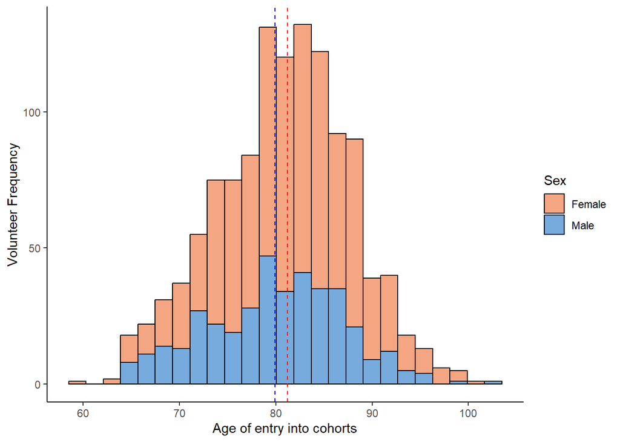

## Age by donors

Age of death is calculated from subtracting date of birth from date of death and dividing the difference by days per year (365.25).

For participants in autopsy cohorts, the exact date of death is known for most participants as it is the day an autopsy was performed. In all cohorts, in addition to annual evaluations, participants are also contacted quarterly to determine vital status and changes in health, and death is occasionally learned of during quarterly contacts.

```
## [1] "Average age of death for women: 90.2314507897934"
```

```
## [1] "Standard deviation: 6.60777105892002"
```

```
## [1] "Average age of death for men: 87.9715426356589"
```

```
## [1] "Standard deviation: 6.38816329552368"
```

```
## [1] "Average age of death overall: 89.5086537190083"
```

```
## [1] "Standard deviation: 6.62021576804519"
```

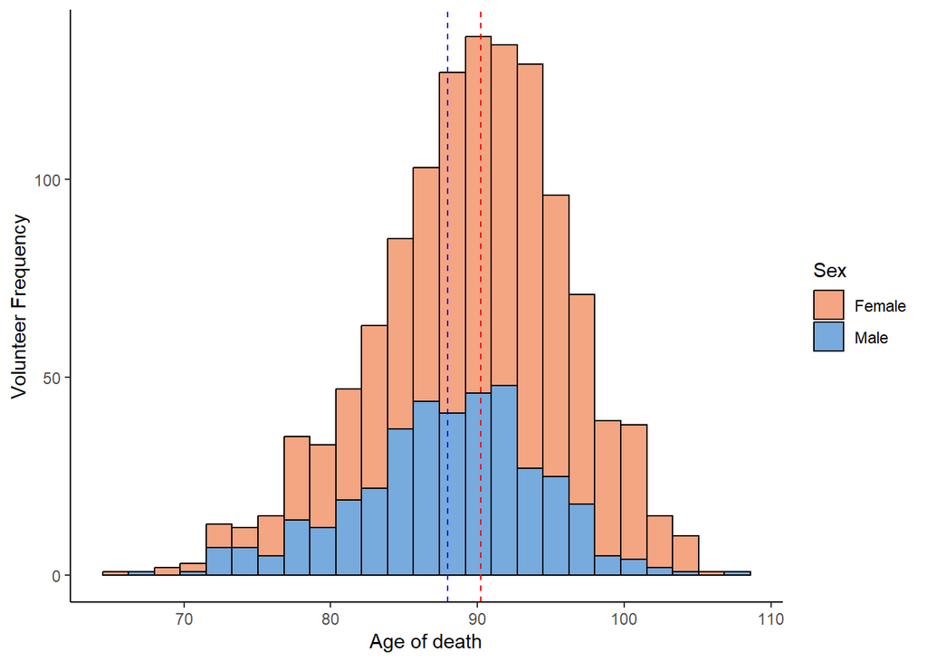

## Years of education (box plot)

The years of education variable is based on the number of years of regular school reported at baseline cognitive testing.

```
## [1] "Average years of formal education for women: 15.7691373025516"
```

```
## [1] "Standard deviation: 3.25070385181732"
```

```
## [1] "Average years of formal education for men: 17.0723514211886"
```

```
## [1] "Standard deviation: 3.8976458153724"
```

```
## [1] "Average years of general formal education: 16.1859504132231"
```

```
## [1] "Standard deviation: 3.52201643934664"
```

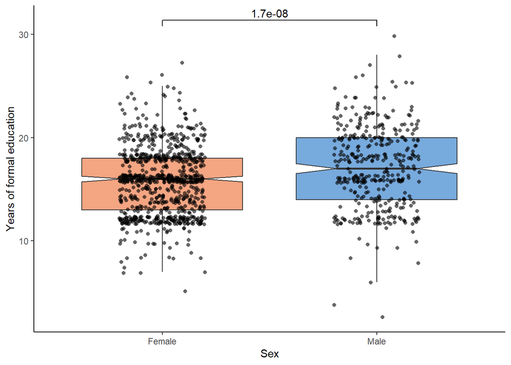

## Donors by cohort

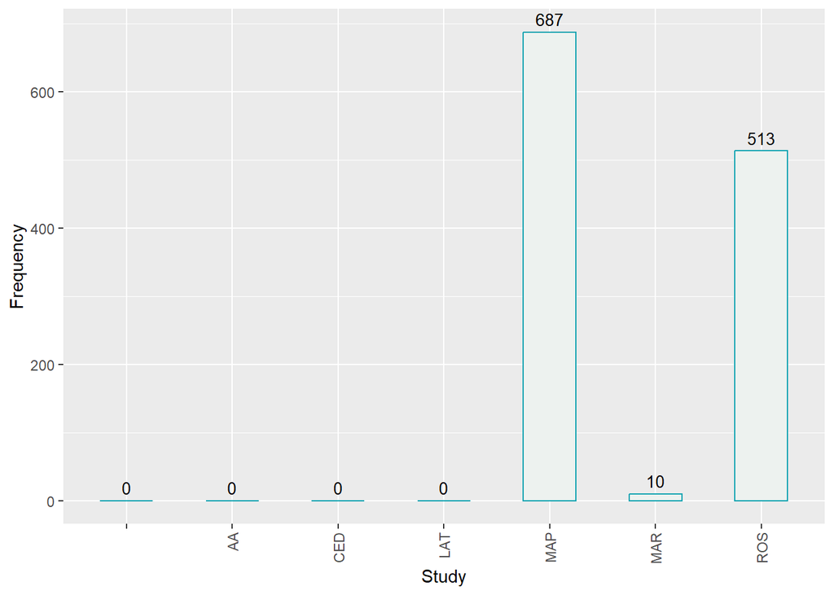

## Race

Race is based on self-report at baseline using the following question:

What is your race?

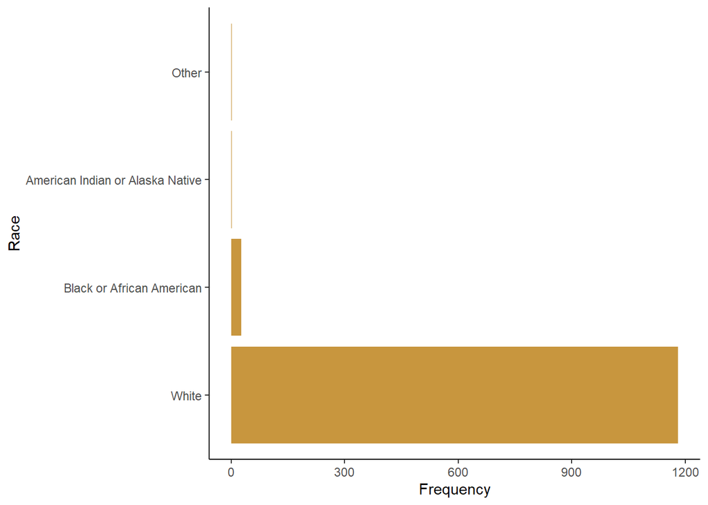

## APOE frequency

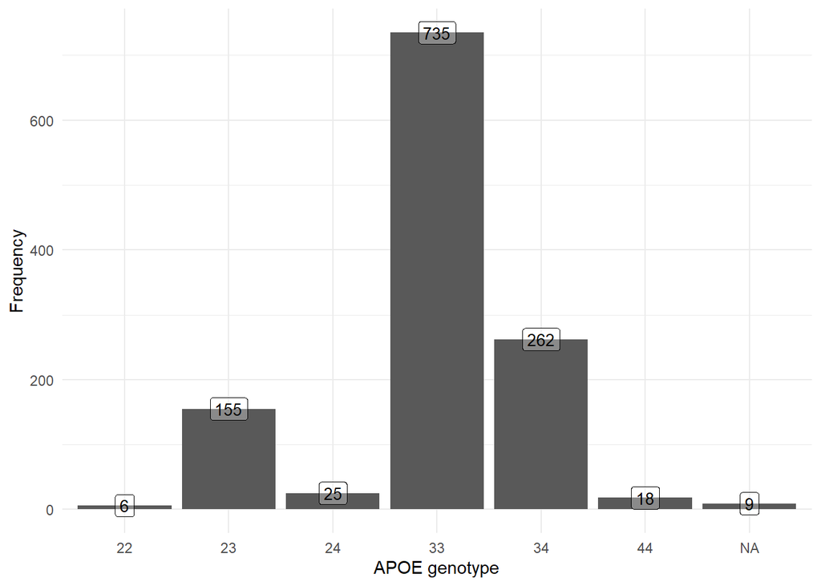

## APOE genotype by diagnosis

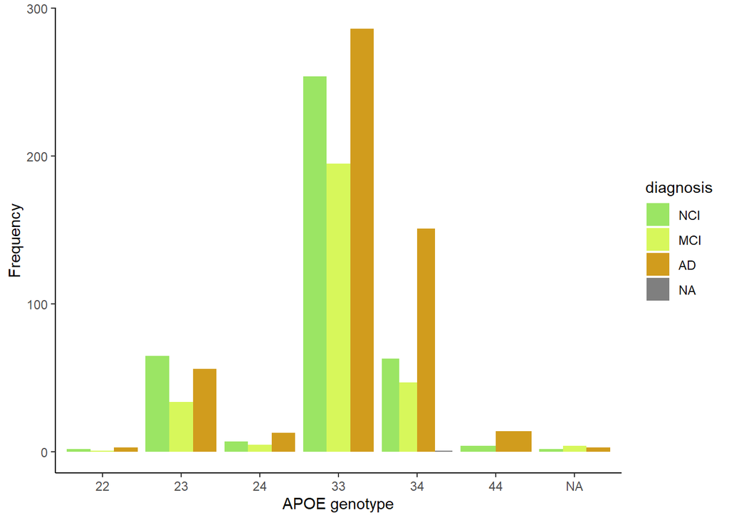

## TOMM40 genotype frequency

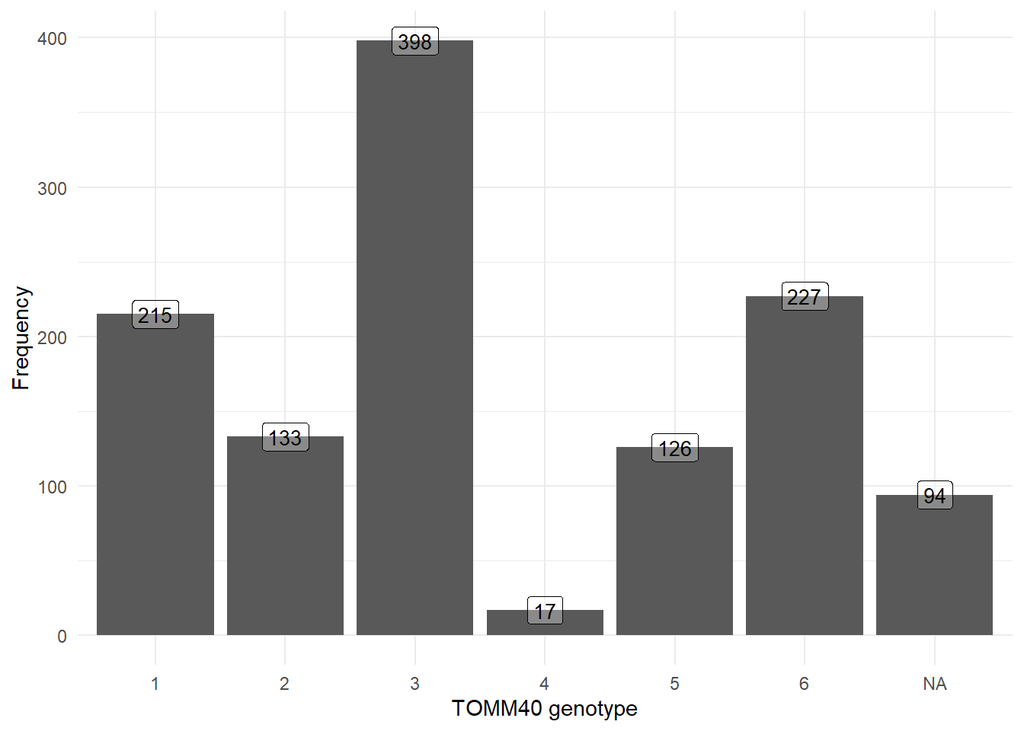

## TOMM40 genotype by diagnosis

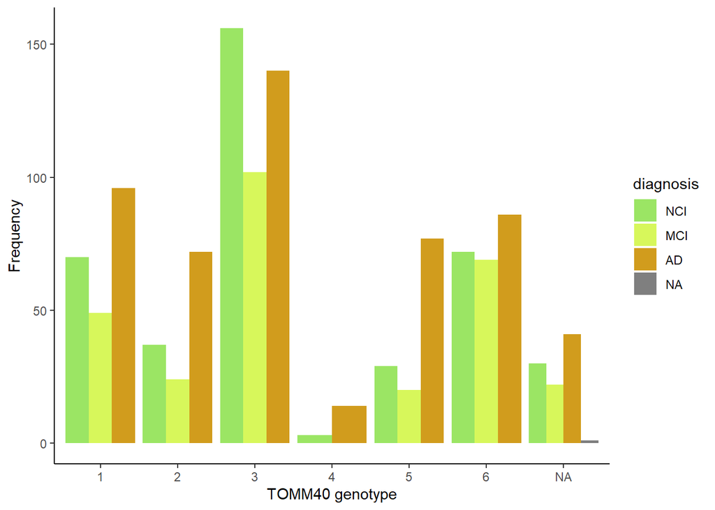